# Global Inequality in Sanitation

Author

Snehaa Selvan

Global Inequality in Sanitation

How unequal access to sanitation continues to shape health and development

“When basic sanitation is missing, inequality becomes visible in the most immediate and human way.”

## Introduction

Access to safe sanitation is one of the most basic indicators of public health and overall development. However, in many parts of the world, this is still not guaranteed. Open defecation — the practice of defecating outside without proper sanitation facilities — continues to be a serious issue, especially in lower-income regions.

In this report, I analyse global inequality in open defecation using the most recent available data for each country. Since reporting years differ across countries, the focus is on the latest recorded values rather than comparing a single year across all countries.

The main goals of this analysis are to: - identify regions where the problem is most severe  
- compare countries with the highest levels  
- understand how sanitation relates to health outcomes  
- observe how the situation has changed over time in high-burden countries

Throughout the report, blue is generally used to represent lower (better) values, while red highlights higher (worse) values, making patterns easier to interpret.

> “Sanitation should be one of the most basic guarantees of public health, yet for millions it remains out of reach.”

## Key Indicators

```python
kpi_avg = latest_pd["open_defecation_pct"].mean()

kpi_max = latest_pd.loc[
    latest_pd["open_defecation_pct"].idxmax()
]

filtered_min = latest_pd[
    latest_pd["open_defecation_pct"] >= 0.15
].copy()

kpi_min = filtered_min.loc[
    filtered_min["open_defecation_pct"].idxmin()
]

kpi_critical = (latest_pd["open_defecation_pct"] > 50).sum()
```

```python
HTML(f"""
<div class="hero-kpis">

  <div class="hero-kpi-card">
    <div class="hero-kpi-value">{kpi_avg:.1f}%</div>
    <div class="hero-kpi-label">Global Average</div>
  </div>

  <div class="hero-kpi-card">
    <div class="hero-kpi-value">{kpi_critical}</div>
    <div class="hero-kpi-label">High-Risk Countries</div>
  </div>

  <div class="hero-kpi-card">
    <div class="hero-kpi-value">{kpi_max['open_defecation_pct']:.1f}%</div>
    <div class="hero-kpi-label">Worst Affected ({kpi_max['country']})</div>
  </div>

  <div class="hero-kpi-card">
    <div class="hero-kpi-value">{kpi_min['open_defecation_pct']:.1f}%</div>
    <div class="hero-kpi-label">Lowest Non-Zero ({kpi_min['country']})</div>
  </div>

</div>
""")
```

4.9%

Global Average

4

High-Risk Countries

67.0%

Worst Affected (Eritrea)

0.2%

Lowest Non-Zero (Samoa)

## Where Is the Problem Most Severe?

The map provides a global view of open defecation rates based on the most recent available data.

What stands out immediately is how uneven the distribution is. The highest rates are concentrated mainly in parts of **Sub-Saharan Africa**, where several countries show very high levels. On the other hand, regions like Europe, North America, and much of East Asia show extremely low rates, reflecting better sanitation systems.

This contrast highlights how closely sanitation is linked to broader development. Countries with higher rates of open defecation often face challenges such as limited infrastructure, lower income levels, and weaker public health systems.

Overall, the map makes it clear that this is not a global issue affecting all countries equally — it is heavily concentrated in specific regions.

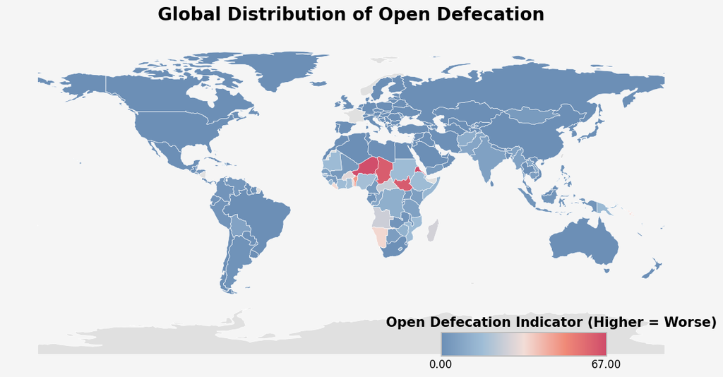

```python
world = gpd.read_file("ne_countries/ne_110m_admin_0_countries.shp")
world = world[["ADMIN", "ISO_A3", "geometry"]]

map_df = world.merge(
    latest_pd,
    how="left",
    left_on="ISO_A3",
    right_on="country_code"
)

cmap = mpl.colors.LinearSegmentedColormap.from_list(
    "blue_to_red_soft",
    ["#6c8fb6", "#9fbdd6", "#f2ddd7", "#f08a78", "#cf4b6a"]
)

vmin = map_df["open_defecation_pct"].min(skipna=True)
vmax = map_df["open_defecation_pct"].max(skipna=True)
norm = mpl.colors.Normalize(vmin=vmin, vmax=vmax)

fig, ax = plt.subplots(figsize=(14, 7), facecolor="#f5f5f5")
ax.set_facecolor("#f5f5f5")

map_df.plot(
    column="open_defecation_pct",
    cmap=cmap,
    linewidth=0.45,
    edgecolor="white",
    missing_kwds={"color": "#e0e0e0"},
    ax=ax
)

ax.axis("off")

ax.set_title(
    "Global Distribution of Open Defecation",
    fontsize=20,
    fontweight="bold",
    pad=18
)

sm = mpl.cm.ScalarMappable(cmap=cmap, norm=norm)
sm._A = []

cax = ax.inset_axes([0.63, 0.04, 0.24, 0.07])
cbar = plt.colorbar(sm, cax=cax, orientation="horizontal")
cbar.outline.set_edgecolor("#bdbdbd")
cbar.outline.set_linewidth(1.4)
cbar.set_ticks([vmin, vmax])
cbar.set_ticklabels([f"{vmin:.2f}", f"{vmax:.2f}"])
cbar.ax.tick_params(labelsize=12, length=0)

ax.text(
    0.55, 0.12,
    "Open Defecation Indicator (Higher = Worse)",
    transform=ax.transAxes,
    fontsize=15,
    fontweight="bold",
    ha="left",
    va="bottom",
    color="black"
)

plt.show()
```

## Which Countries Are Most Affected?

The bar chart focuses on the top 10 countries with the highest open defecation rates.

Countries like **Eritrea, Niger, South Sudan, and Chad** stand out, all with rates above 60%. These countries are all located in Sub-Saharan Africa, which aligns with the pattern observed in the map.

Another thing that becomes clear is the gap between the top few countries and the rest. A small number of countries carry a disproportionately high burden, while others have significantly lower rates even within the top 10.

The colour scheme helps reinforce this difference, with darker red tones highlighting the most severe cases. This makes it easier to see where attention is most urgently needed.

```python
top10 = (
    latest_pd
    .dropna(subset=["open_defecation_pct"])
    .sort_values("open_defecation_pct", ascending=False)
    .head(10)
    .sort_values("open_defecation_pct", ascending=True)
    .copy()
)

top10["label"] = top10["open_defecation_pct"].round(1).astype(str) + "%"
```

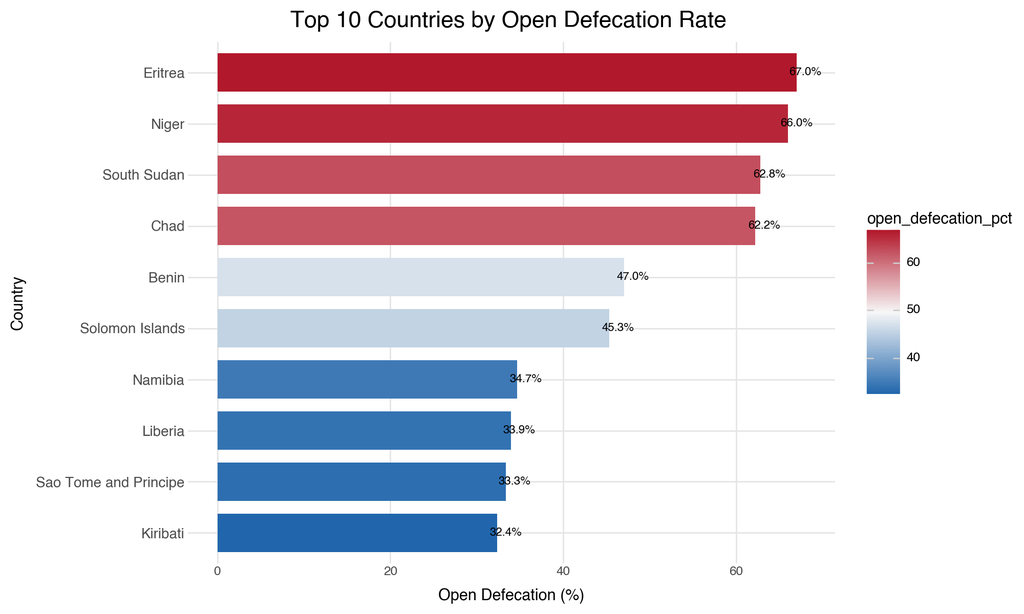

```python
(
    ggplot(top10, aes(x="reorder(country, open_defecation_pct)", y="open_defecation_pct", fill="open_defecation_pct"))
    + geom_col(width=0.75)
    + geom_text(aes(label="label"), nudge_y=1, size=8)
    + scale_fill_gradientn(colors=["#2166ac", "#f7f7f7", "#b2182b"])
    + coord_flip()
    + labs(
        title="Top 10 Countries by Open Defecation Rate ",
        x="Country",
        y="Open Defecation (%)"
    )
    + theme_minimal()
    + theme(
        plot_title=element_text(size=16, weight="bold"),
        axis_text_y=element_text(size=10),
        panel_grid_minor=element_blank(),
        figure_size=(10, 6)
    )
)
```

## The Human Cost: Does Open Defecation Affect Life Expectancy?

This scatterplot explores how open defecation relates to life expectancy across countries.

The size of the points represents population, which adds another layer to the analysis. Some countries with large populations still face significant sanitation challenges, meaning improvements in these areas could have a major impact.

```python
scatter_df = latest_pd.dropna(subset=["open_defecation_pct", "life_expectancy", "population"]).copy()
scatter_df["pop_millions"] = scatter_df["population"] / 1_000_000
```

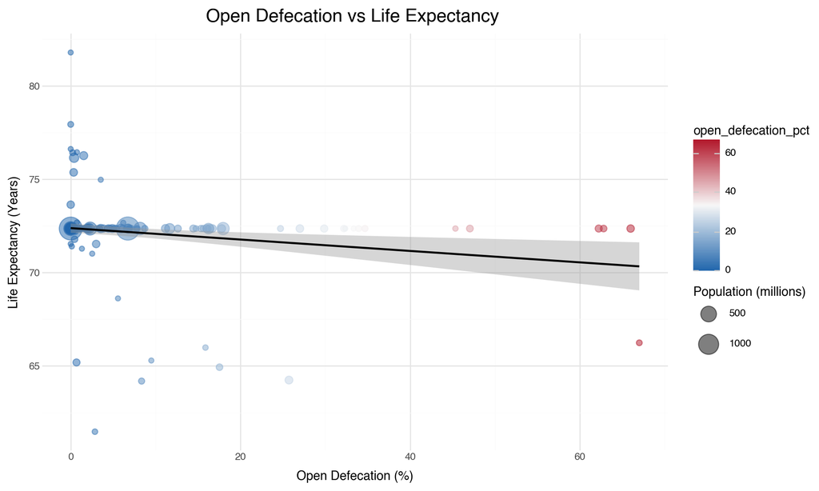

```python
(
    ggplot(scatter_df, aes(x="open_defecation_pct", y="life_expectancy"))
    + geom_point(
        aes(size="pop_millions", color="open_defecation_pct"),
        alpha=0.5
    )
    + geom_smooth(method="lm", color="black")
    + scale_color_gradientn(colors=["#2166ac", "#f7f7f7", "#b2182b"])
    + scale_size_continuous(name="Population (millions)", range=(2, 11))
    + labs(
        title="Open Defecation vs Life Expectancy ",
        x="Open Defecation (%)",
        y="Life Expectancy (Years)"
    )
    + theme_minimal()
    + theme(
        plot_title=element_text(size=16, weight="bold"),
        figure_size=(10, 6)
    )
)
```

## Is Anything Changing Over Time?

The time series plot tracks how open defecation rates have changed over time in selected high-burden countries.

Encouragingly, all countries show a gradual decline, which suggests that progress is being made. However, the pace of improvement varies, and the levels in some countries are still relatively high.

Countries that currently have higher rates also tend to have remained higher over time, indicating that inequality between countries has not fully closed.

Another noticeable point is that not all countries are improving at the same rate. Some show faster reductions, while others decline more slowly.

This suggests that while global progress is happening, it is uneven, and targeted efforts are still needed in the most affected regions.

```python
focus_countries = (
    latest_pd
    .dropna(subset=["open_defecation_pct"])
    .sort_values("open_defecation_pct", ascending=False)
    .head(6)["country"]
    .tolist()
)

ts_df = clean_pd[clean_pd["country"].isin(focus_countries)].copy()

severity_map = (
    latest_pd[["country", "open_defecation_pct"]]
    .dropna()
    .set_index("country")["open_defecation_pct"]
    .to_dict()
)

ts_df["severity_latest"] = ts_df["country"].map(severity_map)
```

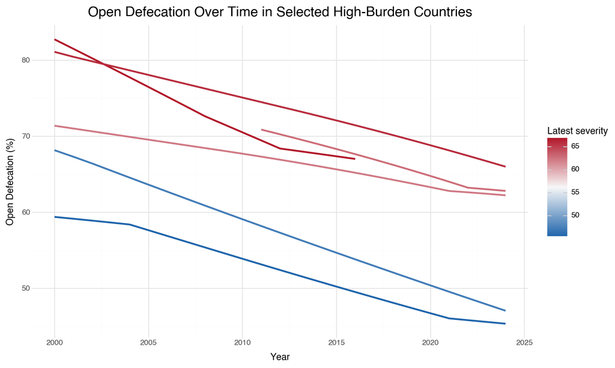

```python
(
    ggplot(ts_df, aes(x="year", y="open_defecation_pct", group="country", color="severity_latest"))
    + geom_line(size=1.2)
    + scale_color_gradientn(
        colors=["#2166ac", "#f7f7f7", "#b2182b"],
        name="Latest severity"
    )
    + labs(
        title="Open Defecation Over Time in Selected High-Burden Countries",
        x="Year",
        y="Open Defecation (%)"
    )
    + theme_minimal()
    + theme(
        plot_title=element_text(size=16, weight="bold"),
        figure_size=(10, 6)
    )
)
```

## Summary table

```python
top10 = (
    latest_pd
    .dropna(subset=["open_defecation_pct"])
    .sort_values("open_defecation_pct", ascending=False)
    .head(10)
    .copy()
)

top10_display = top10[[
    "country",
    "latest_year",
    "open_defecation_pct",
    "life_expectancy",
    "population"
]].reset_index(drop=True)

top10_display["open_defecation_pct"] = top10_display["open_defecation_pct"].round(1)
top10_display["life_expectancy"] = top10_display["life_expectancy"].round(1)

top10_display
```

|  | country | latest_year | open_defecation_pct | life_expectancy | population |
| --- | --- | --- | --- | --- | --- |
| 0 | Eritrea | 2016 | 67.0 | 66.2 | 3124698.0 |
| 1 | Niger | 2024 | 66.0 | 72.4 | 27032412.0 |
| 2 | South Sudan | 2024 | 62.8 | 72.4 | 11943408.0 |
| 3 | Chad | 2024 | 62.2 | 72.4 | 20299123.0 |
| 4 | Benin | 2024 | 47.0 | 72.4 | 14462724.0 |
| 5 | Solomon Islands | 2024 | 45.3 | 72.4 | 819198.0 |
| 6 | Namibia | 2024 | 34.7 | 72.4 | 6661512.0 |
| 7 | Liberia | 2024 | 33.9 | 72.4 | 5612817.0 |
| 8 | Sao Tome and Principe | 2024 | 33.3 | 72.4 | 235536.0 |
| 9 | Kiribati | 2024 | 32.4 | 72.4 | 134518.0 |

## Conclusion

This analysis highlights the unequal distribution of sanitation access across the world. Open defecation remains concentrated in specific regions, particularly in Sub-Saharan Africa, while many other parts of the world have already achieved very low levels.

Although the overall trend is improving, the persistence of high levels in certain countries shows that more focused efforts are still required.

Improving sanitation is not just about infrastructure — it directly affects health, dignity, and quality of life. Addressing these gaps will be essential for achieving more equal global development.

**Author:** Snehaa Selvan  
**Data Source:** UNICEF — Open Defecation and Sanitation Indicators  
© 2026 | BAA1030 Data Analytics and Story Framing